# GARCH Modeling

## Load Required Libraries

```r
# install.packages(c("quantmod", "zoo", "ggplot2", "tseries", "rugarch",
#  "bayesGARCH", "stats", "timeDate", "timeSeries",
#  "forecast"),
#  dependencies = TRUE, repos = "https://cloud.r-project.org/")

suppressPackageStartupMessages({
  library(quantmod) # for getSymbols
  library(zoo) # for na.omit
  library(ggplot2) # for plotting
  library(tseries) # for adf.test
  library(rugarch) # for GARCH modeling
  library(bayesGARCH) # for Bayesian GARCH
  library(stats) # for spectrum, acf, pacf
  library(timeDate) # for business days
  library(timeSeries) # for holidaySIFMA
  library(forecast) # for auto.arima
  library(xts)
  library(strucchange)
})
```

## Load and Plot 10-Year Treasury Yield Data

```r
# "Market Yield on U.S. Treasury Securities at 10-Year Constant Maturity,
# Quoted on an Investment Basis"

range_date_from <- "2010-01-01" # start date for data
range_date_to <- format(Sys.Date() - 7, "%Y-%m-%d") # end date - last week
print(paste("Loading DGS10 data from", range_date_from, "to", range_date_to))
```

```
## [1] "Loading DGS10 data from 2010-01-01 to 2025-07-22"
```

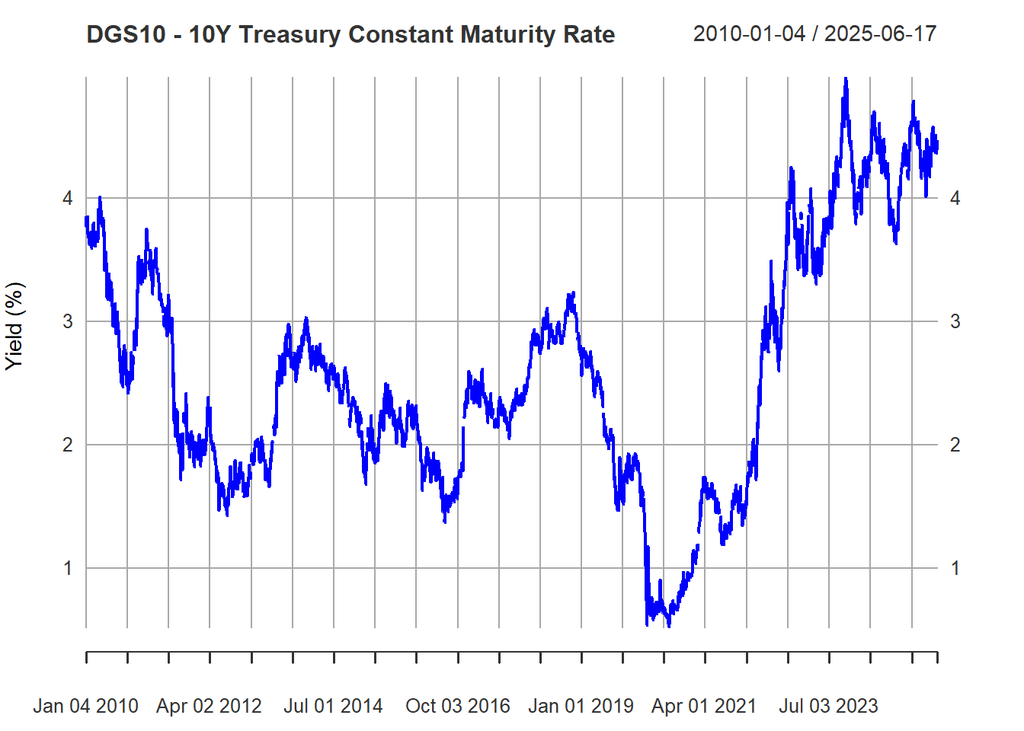

```r
#getSymbols("DGS10", src = "FRED", from = range_date_from, to = range_date_to) # until yesterday
DGS10 <- read.csv("DGS10.csv")
DGS10 <- xts(DGS10$DGS10, order.by = as.Date(DGS10$observation_date))
plot(DGS10, main = "DGS10 - 10Y Treasury Constant Maturity Rate",
     col = "blue", ylab = "Yield (%)", xlab = "Date")
```

The yield curve clearly shows three regimes: post-GFC low rates, pandemic crash (~2020), and sharp rise post-2022 (inflation, Fed tightening). Some missing values are visible.

## Preliminary Data Analysis

### Check for Missing Values

```r
# Helper functions
get_year_as_num <- function(date) as.numeric(format(as.Date(date), "%Y"))
is_bizday <- function(dates) {
  years <- get_year_as_num(range_date_from):get_year_as_num(range_date_to)
  holidays <- as.Date(holidayNYSE(years))
  # Columbus Day, Veterans Day, National Day of Mourning
  extra_holidays <-as.Date(
      c("2010-10-11", "2010-11-11", "2011-10-10", "2011-11-11", "2012-10-08",
        "2012-11-12", "2013-10-14", "2013-11-11", "2014-10-13", "2014-11-11",
        "2015-10-12", "2015-11-11", "2016-10-10", "2016-11-11", "2017-10-09",
        "2018-10-08", "2018-11-12", "2018-12-05", "2019-10-14", "2019-11-11",
        "2020-10-12", "2020-11-11", "2021-10-11", "2021-11-11", "2022-10-10",
        "2022-11-11", "2023-10-09", "2024-10-14", "2024-11-11"))
  holidays <- timeDate(sort(unique(c(holidays, extra_holidays))))

  isBizday(dates, holidays)
}

# analysis of all days in the range
temp_time_seq <- timeSequence(from = range_date_from,
                              to = range_date_to,
                              by = "day")
all_dates <- as.Date(temp_time_seq)
business_days <- as.Date(temp_time_seq[is_bizday(temp_time_seq)])
non_business_days <- as.Date(setdiff(all_dates, business_days))
earliest_date <- min(all_dates)
latest_date <- max(all_dates)

# dates in DGS10
days_in_data <- index(DGS10)
duplicate_days_in_data <- days_in_data[duplicated(days_in_data)]
business_days_in_data <- business_days[business_days %in% days_in_data]
non_business_days_in_data <- as.Date(non_business_days[non_business_days %in%
                                                       days_in_data])
earliest_date_in_data <- min(days_in_data)
latest_date_in_data <- max(days_in_data)
real_days_in_data <- days_in_data[days_in_data %in% all_dates]
missing_days <- as.Date(setdiff(all_dates, days_in_data))
missing_business_days <- as.Date(setdiff(business_days, days_in_data))
missing_non_business_days <- as.Date(setdiff(non_business_days, days_in_data))

# Analysis of NAs
days_with_na_in_data <- index(DGS10[is.na(DGS10)])
business_days_with_na_in_data <- business_days[business_days %in%
                                                 days_with_na_in_data]
non_business_days_with_na <- non_business_days[non_business_days %in%
                                                 days_with_na_in_data]
# printing results
cat("Business Days in Data:", length(business_days_in_data), "\n")
```

```
## Business Days in Data: 3861
```

```r
cat("Non-Business Days in Data:", length(non_business_days_in_data), "\n")
```

```
## Non-Business Days in Data: 171
```

```r
cat("Missing Days in Data:", length(missing_days), "\n")
```

```
## Missing Days in Data: 1650
```

```r
cat("Missing Business Days in Data:", length(missing_business_days),
    paste(missing_business_days, collapse = ", "), "\n")
```

```
## Missing Business Days in Data: 23 2025-06-18, 2025-06-20, 2025-06-23, 2025-06-24, 2025-06-25, 2025-06-26, 2025-06-27, 2025-06-30, 2025-07-01, 2025-07-02, 2025-07-03, 2025-07-07, 2025-07-08, 2025-07-09, 2025-07-10, 2025-07-11, 2025-07-14, 2025-07-15, 2025-07-16, 2025-07-17, 2025-07-18, 2025-07-21,…
```

```r
cat("Missing Non-Business Days in Data:", length(missing_non_business_days), "\n")
```

```
## Missing Non-Business Days in Data: 1627
```

```r
print("\n")
```

```
## [1] "\n"
```

```r
cat("Days with NA in Data:", length(days_with_na_in_data), "\n")
```

```
## Days with NA in Data: 165
```

```r
cat("Business Days with NA in Data:", length(business_days_with_na_in_data), "\n")
```

```
## Business Days with NA in Data: 0
```

```r
cat("Non-Business Days with NA in Data:", length(non_business_days_with_na), "\n")
```

```
## Non-Business Days with NA in Data: 165
```

```r
print("\n")
```

```
## [1] "\n"
```

```r
cat("Business Days with NA in Data:", paste(business_days_with_na_in_data, collapse = ", "), "\n")
```

```
## Business Days with NA in Data:
```

### Removing NAs

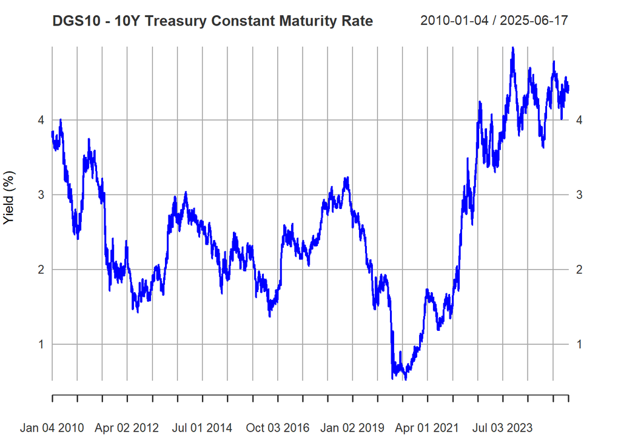

```r
DGS10 <- na.omit(DGS10)
plot(DGS10, main = "DGS10 - 10Y Treasury Constant Maturity Rate",
     col = "blue", ylab = "Yield (%)", xlab = "Date")
```

### Check for Stationarity

```r
# testing if its stationary
adf.test(DGS10, alternative = "stationary")
```

```
##
##  Augmented Dickey-Fuller Test
##
## data:  DGS10
## Dickey-Fuller = -1.8636, Lag order = 15, p-value = 0.6361
## alternative hypothesis: stationary
```

p-value is very large, so we have to accept H0 –> data is not stationary  
GARCH models require weakly stationary time series which can be tested with ADF

Compute daily changes, first difference to make it stationary.

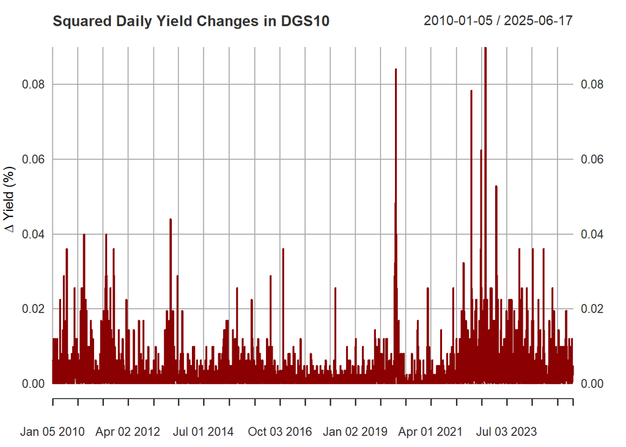

```r
# diff computes the daily change. The first value is NA since there is no
# previous value to subtract from the first one, so we remove it.
DGS10_diff <- diff(DGS10)[-1]
DGS10_diff_sq <- DGS10_diff^2
colnames(DGS10_diff_sq) <- "SquaredDailyChange"
plot(DGS10_diff_sq, main = "Squared Daily Yield Changes in DGS10",
     col = "darkred", ylab = "∆ Yield (%)", xlab = "Date")
```

Major spikes around early 2020 (pandemic) and post-2022 (inflation uncertainty)

```r
# testing stationarity of the daily changes
adf.test(DGS10_diff_sq)
```

```
##
##  Augmented Dickey-Fuller Test
##
## data:  DGS10_diff_sq
## Dickey-Fuller = -10.357, Lag order = 15, p-value = 0.01
## alternative hypothesis: stationary
```

p-value is very low, so we can say that the data is weakly stationary now (there is enough statistical evidence to reject H0).

### Frequency Spectrum of Daily Changes

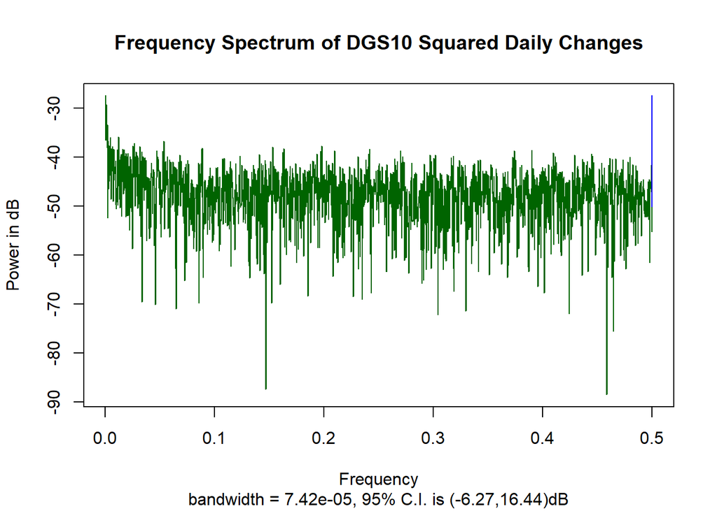

```r
# Frequency spectrum of daily changes
spectrum(DGS10_diff_sq, method = "pgram",
         main = "Frequency Spectrum of DGS10 Squared Daily Changes",
         col = "darkgreen", ylab = "Power in dB", xlab = "Frequency",
         log = "dB")
```

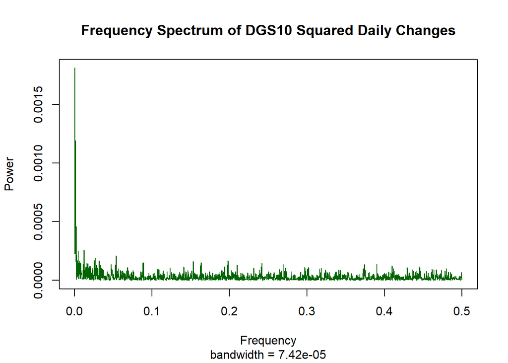

```r
spectrum(DGS10_diff_sq, method = "pgram",
         main = "Frequency Spectrum of DGS10 Squared Daily Changes",
         col = "darkgreen", ylab = "Power", xlab = "Frequency",
         log = "no")
```

The spectrum is relatively flat with higher power at very low frequencies. The spike near 0 indicates long-memory or persistent behavior in volatility. The high power at low frequencies implies low-frequency (long-term) cycles dominate.

### ACF and PACF of Daily Changes

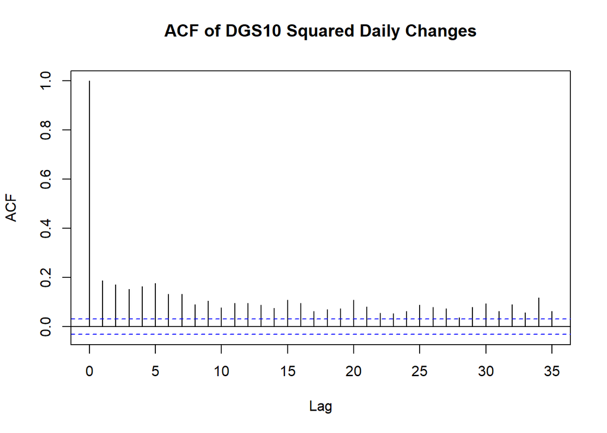

```r
acf(DGS10_diff_sq, main = "ACF of DGS10 Squared Daily Changes")
```

The ACF decays slowly and remains statistically significant for many lags. Reinforces the presence of volatility clustering. Suggests that past squared returns can predict future volatility to some extent.

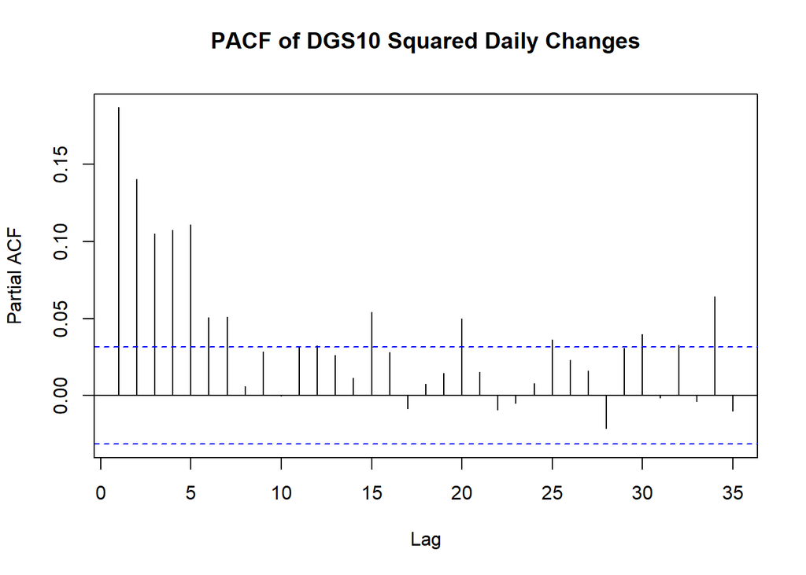

```r
pacf(DGS10_diff_sq, main = "PACF of DGS10 Squared Daily Changes")
```

The PACF shows significant spikes up to lag ~7, especially lags 1–5. This suggests that the squared daily changes exhibit short-term persistence or clustering. There is conditional heteroskedasticity, supporting the use of ARCH/GARCH models for volatility modeling.

## GARCH Model Specification and Fitting

### Mean model selection

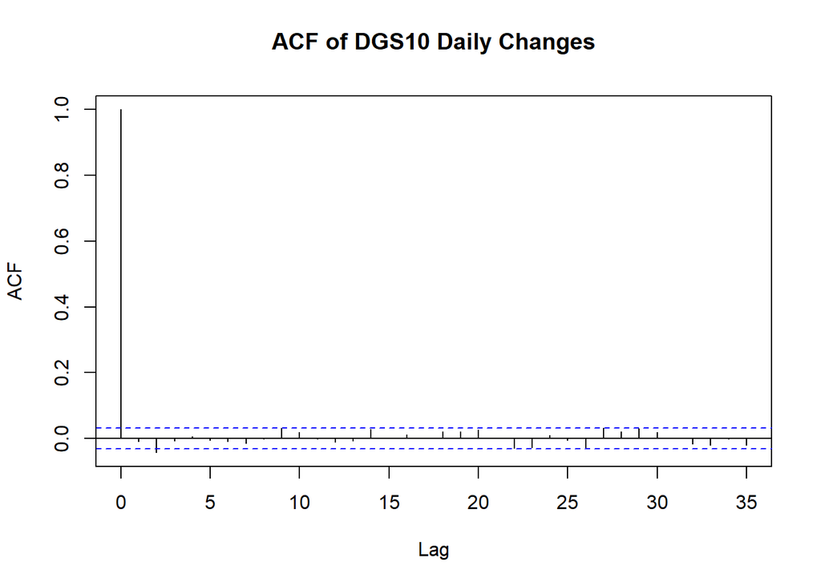

```r
acf(DGS10_diff, main = "ACF of DGS10 Daily Changes")
```

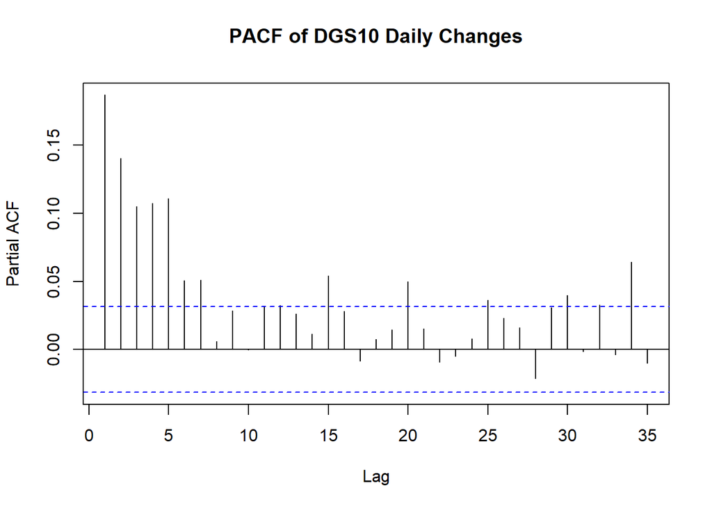

```r
pacf(DGS10_diff_sq, main = "PACF of DGS10 Daily Changes")
```

```r
auto.arima(coredata(DGS10_diff),
           d = 0, # already differenced
           max.p = 10, max.q = 10,
           stationary = TRUE,
           seasonal = FALSE)
```

```
## Series: coredata(DGS10_diff)
## ARIMA(0,0,0) with zero mean
##
## sigma^2 = 0.002924:  log likelihood = 5792.95
## AIC=-11583.9   AICc=-11583.9   BIC=-11577.64
```

The mean of the differenced yield series (i.e. daily yield changes) is not statistically different from zero. –> mean model: ARIMA(0,0,0) with zero mean The ACF also supports this selection because we don’t see any significant autocorrelation there.

### Model Fitting

We should use the simple differenced data (not the squared values). The squared resiudals are implicitly handled inside the GARCH model.

```r
# standard GARCH(1,1) model with Student-t innovations
# on the first difference of the 10-year Treasury yield series
spec <- ugarchspec(
  variance.model = list(model = "sGARCH", garchOrder = c(1, 1)),
  # mean model with no ARMA terms, just a constant mean
  mean.model = list(armaOrder = c(0, 0), include.mean = FALSE),
  # Student-t distribution, assumed distribution of shocks/random errors
  distribution.model = "std"
)

fit <- ugarchfit(spec, DGS10_diff)
show(fit)
```

```
##
## *---------------------------------*
## *          GARCH Model Fit        *
## *---------------------------------*
##
## Conditional Variance Dynamics
## -----------------------------------
## GARCH Model  : sGARCH(1,1)
## Mean Model   : ARFIMA(0,0,0)
## Distribution : std
##
## Optimal Parameters
## ------------------------------------
##         Estimate  Std. Error  t value Pr(>|t|)
## omega   0.000025    0.000009   2.6775 0.007416
## alpha1  0.050429    0.008374   6.0220 0.000000
## beta1   0.941417    0.010244  91.8994 0.000000
## shape  12.971401    2.228214   5.8214 0.000000
##
## Robust Standard Errors:
##         Estimate  Std. Error  t value Pr(>|t|)
## omega   0.000025    0.000012   2.0981 0.035898
## alpha1  0.050429    0.013125   3.8421 0.000122
## beta1   0.941417    0.015917  59.1465 0.000000
## shape  12.971401    2.261892   5.7348 0.000000
##
## LogLikelihood : 6075.197
##
## Information Criteria
## ------------------------------------
##
## Akaike       -3.1408
## Bayes        -3.1343
## Shibata      -3.1408
## Hannan-Quinn -3.1385
##
## Weighted Ljung-Box Test on Standardized Residuals
## ------------------------------------
##                         statistic p-value
## Lag[1]                     0.3842  0.5354
```

[output cut: 37 more lines]

```
## Negative Sign Bias 1.29610 0.1950
## Positive Sign Bias 0.60101 0.5479
## Joint Effect       2.41807 0.4903
##
##
## Adjusted Pearson Goodness-of-Fit Test:
## ------------------------------------
##   group statistic p-value(g-1)
## 1    20     286.2    1.328e-49
## 2    30     590.4   6.290e-106
## 3    40     924.9   1.086e-168
## 4    50    1187.4   1.833e-216
##
##
## Elapsed time : 0.5590189
```

### GARCH model selection with grid search

Testing GARCH(p, q, distribution) with parameters $p, q \in \{1, ..., 5\}$, and distribution for normal and student-t.

```r
best_aic <- Inf
best_spec <- NULL
best_fit <- NULL
distributions <- c("norm", "std")

for (dist in distributions){
  for (p in 1:5) {
    for (q in 1:5) {
      spec <- ugarchspec(
        variance.model = list(model = "sGARCH", garchOrder = c(p, q)),
        mean.model = list(armaOrder = c(0, 0), include.mean = TRUE),
        distribution.model = dist
      )
      fit <- tryCatch(ugarchfit(spec, DGS10_diff, solver = "hybrid"), error = function(e) NULL)

      if (!is.null(fit)) {
        aic <- infocriteria(fit)[1]  # [1] = AIC
        if (aic < best_aic) {
          best_aic <- aic
          best_spec <- spec
          best_fit <- fit
        }
      }
    }
  }
}

show(best_fit)
```

```
##
## *---------------------------------*
## *          GARCH Model Fit        *
## *---------------------------------*
##
## Conditional Variance Dynamics
## -----------------------------------
## GARCH Model  : sGARCH(1,1)
## Mean Model   : ARFIMA(0,0,0)
## Distribution : std
##
## Optimal Parameters
## ------------------------------------
##         Estimate  Std. Error   t value Pr(>|t|)
## mu      0.000031    0.000739  0.041265 0.967085
## omega   0.000025    0.000009  2.677857 0.007409
## alpha1  0.050425    0.008372  6.023040 0.000000
## beta1   0.941421    0.010241 91.923659 0.000000
## shape  12.975598    2.231321  5.815209 0.000000
##
## Robust Standard Errors:
##         Estimate  Std. Error   t value Pr(>|t|)
## mu      0.000031    0.000693  0.044031 0.964880
## omega   0.000025    0.000012  2.098808 0.035834
## alpha1  0.050425    0.013114  3.845134 0.000120
## beta1   0.941421    0.015903 59.199118 0.000000
## shape  12.975598    2.259114  5.743667 0.000000
##
## LogLikelihood : 6075.198
##
## Information Criteria
## ------------------------------------
##
## Akaike       -3.1403
## Bayes        -3.1322
## Shibata      -3.1403
## Hannan-Quinn -3.1374
##
## Weighted Ljung-Box Test on Standardized Residuals
## ------------------------------------
```

[output cut: 40 more lines]

```
## Negative Sign Bias  1.6374 0.1016
## Positive Sign Bias  0.2164 0.8287
## Joint Effect        2.7310 0.4350
##
##
## Adjusted Pearson Goodness-of-Fit Test:
## ------------------------------------
##   group statistic p-value(g-1)
## 1    20     287.1    8.697e-50
## 2    30     593.6   1.398e-106
## 3    40     920.2   1.035e-167
## 4    50    1185.2   5.139e-216
##
##
## Elapsed time : 0.5754571
```

### Inspecting the fit of the model - standardized residual diagnostics

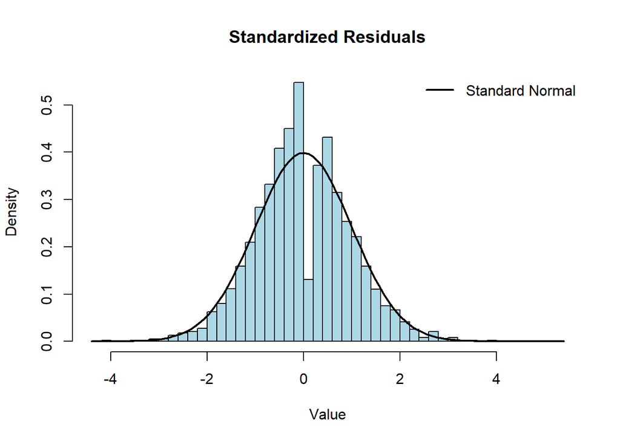

```r
spec_norm <- ugarchspec(
  variance.model = list(model = "sGARCH", garchOrder = c(1, 1)),
  mean.model = list(armaOrder = c(0, 0)),
  distribution.model = "std"
)
fit_norm <- ugarchfit(spec_norm, DGS10_diff)

resids <- residuals(fit_norm, standardize = TRUE)

hist(resids, breaks = 50, freq = FALSE, col = "lightblue",
     main = "Standardized Residuals",
     xlab = "Value")

# Add standard normal density curve
curve(dnorm(x, mean = 0, sd = 1), col = "black", lwd = 2, add = TRUE)

# Add legend
legend("topright", legend = "Standard Normal",
       col = "black", lwd = 2, bty = "n")
```

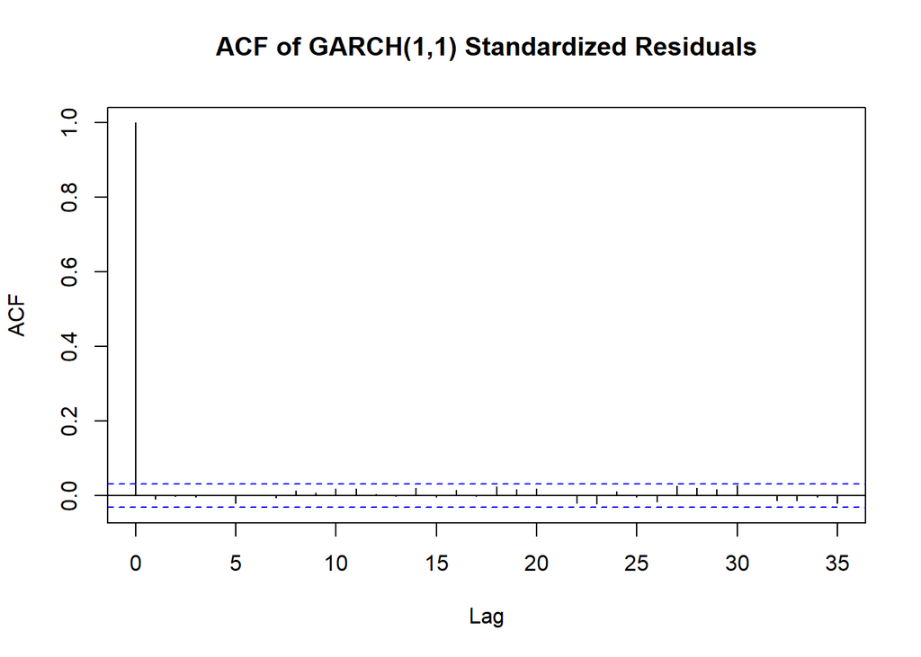

```r
acf(resids, main = "ACF of GARCH(1,1) Standardized Residuals")
```

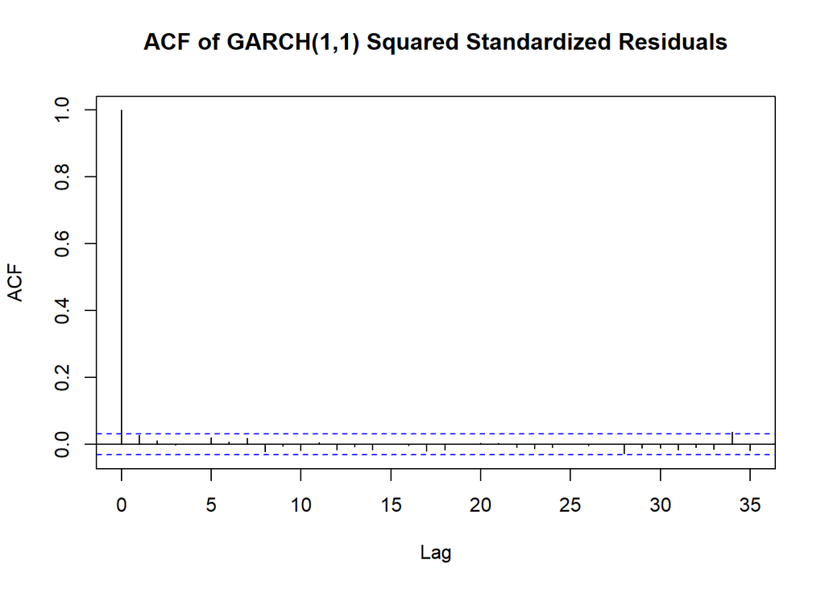

```r
acf(resids^2, main = "ACF of GARCH(1,1) Squared Standardized Residuals")
```

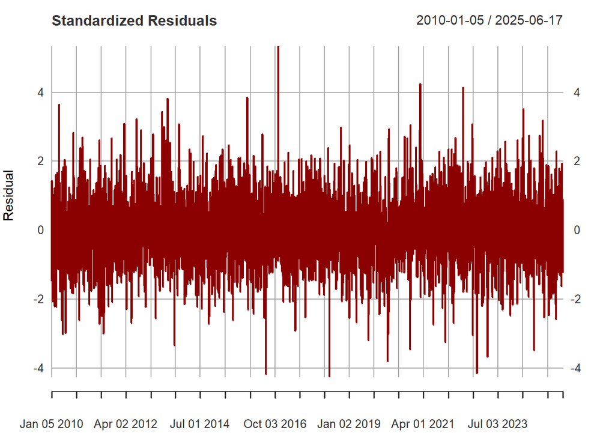

```r
plot(resids, type = "l", main = "Standardized Residuals",
     ylab = "Residual", xlab = "Time", col = "darkred")
```

Also, the selected model is backed up by the results: the standardized residuals are approximately standard normal, there is no autocorrelation between either the residuals or the squared residuals. The residuals seem to be more or less homoscedastic - at least there is less volatility clustering.

### GARCH with MLE, rolling prediction for the last 3 months

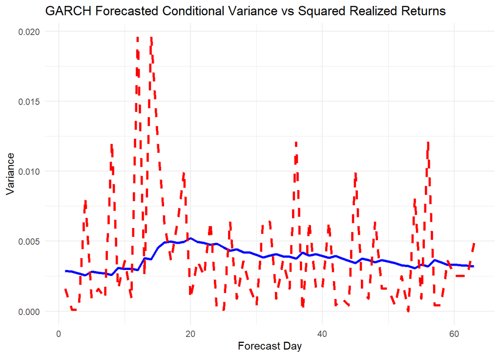

```r
# Length of time series
N <- length(DGS10_diff)

# Set forecast length to ~3 months (63 trading days)
forecast_horizon <- 63

# Define train/test
train <- DGS10_diff[1:(N - forecast_horizon)]
test <- DGS10_diff[(N - forecast_horizon + 1):N]

# GARCH(1,1) specification with Student-t errors
spec <- ugarchspec(
  variance.model = list(model = "sGARCH", garchOrder = c(1, 1)),
  mean.model = list(armaOrder = c(0, 0), include.mean = TRUE),
  distribution.model = "std"
)

# Rolling 1-day ahead forecast
roll <- ugarchroll(
  spec,
  data = DGS10_diff,
  forecast.length = forecast_horizon,
  refit.every = 1,
  refit.window = "moving",
  solver = "hybrid",
  calculate.VaR = FALSE
)

# Extract forecasted sigma (volatility)
forecasted_sigma <- as.numeric(roll@forecast$density[, "Sigma"])
forecasted_var <- forecasted_sigma^2  # conditional variance

# Use squared returns as proxy for realized volatility
realized_returns <- tail(DGS10_diff, forecast_horizon)
realized_vol <- realized_returns^2

# Data for plotting
comparison_df <- data.frame(
  Day = 1:forecast_horizon,
  ForecastedVar = forecasted_var,
  RealizedVar = realized_vol
)

# Plot
ggplot(comparison_df, aes(x = Day)) +
  geom_line(aes(y = ForecastedVar), color = "blue", size = 1.2) +
  geom_line(aes(y = RealizedVar), color = "red", linetype = "dashed", size = 1.2) +
  labs(
    title = "GARCH Forecasted Conditional Variance vs Squared Realized Returns",
    y = "Variance", x = "Forecast Day"
  ) +
  theme_minimal()
```

3 months prediction: GARCH catches the trends but reacts slowly to them.

### GARCH With Indicators

```r
# Setup
N <- length(DGS10_diff)
forecast_horizon <- 63
full_index <- index(DGS10_diff)
realized_returns <- tail(DGS10_diff, forecast_horizon)
realized_var <- realized_returns^2

# Define rolling predictions container
forecasted_var_with_indicators <- numeric(forecast_horizon)

# Create full event matrix matching the entire series
event_indicators_full <- data.frame(
  COVID = ifelse(full_index >= as.Date("2020-03-01") & full_index <= as.Date("2020-05-15"), 1, 0),
  EnergyFed2022 = ifelse(full_index >= as.Date("2022-03-01") & full_index <= as.Date("2022-10-01"), 1, 0),
  PreElection = ifelse(full_index >= as.Date("2023-12-01") & full_index <= as.Date("2024-06-15"), 1, 0)
)

# Rolling forecast with external regressors
for (i in 1:forecast_horizon) {

  # Subset data up to time t + i - 1
  train_slice <- DGS10_diff[1:(N - forecast_horizon + i - 1)]
  reg_slice <- event_indicators_full[1:(N - forecast_horizon + i - 1), ]

  # Take the matching regressors for variance equation
  spec_step <- ugarchspec(
    variance.model = list(model = "sGARCH", garchOrder = c(1, 1),
                          external.regressors = as.matrix(reg_slice)),
    mean.model = list(armaOrder = c(0, 0), include.mean = TRUE),
    distribution.model = "std"
  )

  # Fit and forecast
  fit_step <- ugarchfit(spec_step, train_slice, solver = "hybrid", solver.control = list(trace = 0))
  fc <- ugarchforecast(fit_step, n.ahead = 1)
  forecasted_var_with_indicators[i] <- sigma(fc)^2
}
```

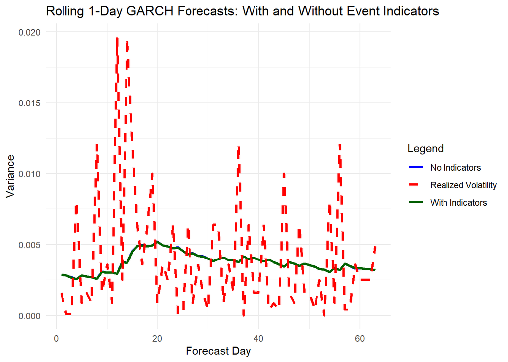

```r
# Comparison dataframe
comparison_df <- data.frame(
  Day = 1:forecast_horizon,
  RealizedVar = realized_var,
  ForecastedVar_NoIndicators = forecasted_var,  # from ugarchroll
  ForecastedVar_Indicators = forecasted_var_with_indicators
)

ggplot(comparison_df, aes(x = Day)) +
  geom_line(aes(y = ForecastedVar_NoIndicators, color = "No Indicators"), size = 1.2) +
  geom_line(aes(y = ForecastedVar_Indicators, color = "With Indicators"), size = 1.2) +
  geom_line(aes(y = RealizedVar, color = "Realized Volatility"), linetype = "dashed", size = 1.2) +
  scale_color_manual(values = c("No Indicators" = "blue",
                                "With Indicators" = "darkgreen",
                                "Realized Volatility" = "red")) +
  labs(
    title = "Rolling 1-Day GARCH Forecasts: With and Without Event Indicators",
    y = "Variance", x = "Forecast Day",
    color = "Legend"
  ) +
  theme_minimal()
```

## Key Event Modelling using GARCH

Estimate a model with 2025 as the test set and everything before as the training set. Additionally, modelling some key events (COVID, first TRUMP term) using inidcators as key events.

```r
# Using data DGS10
train_start <- "2010-01-01"
train_end <- "2025-04-30"
train_data <- DGS10_diff[paste0(train_start, "/", train_end)]
colnames(train_data) <- "Vola"
test_data <- na.omit(DGS10_diff["2025-05-01/"])
spec <- ugarchspec(
  variance.model = list(model = "sGARCH", garchOrder = c(1, 1)),
  mean.model = list(armaOrder = c(0, 0), include.mean = TRUE),
  distribution.model = "std"
)
fit_no_indicators <- ugarchfit(spec, train_data)
# Extract residuals and squared residuals
residuals_train <- residuals(fit_no_indicators, standardize = TRUE)
squared_residuals_train <- residuals(fit_no_indicators, standardize = FALSE)^2
```

```r
# Create indicators for key events
key_events <- data.frame(
  COVID = ifelse(index(train_data) >= as.Date("2020-03-01"), 1, 0),
  Trump = ifelse(index(train_data) >= as.Date("2016-11-08") & index(train_data) <= as.Date("2020-01-20"), 1, 0),
  Energy = ifelse(index(train_data) >= as.Date("2022-01-01"), 1, 0)
)
# Fit GARCH model with indicators
spec_with_indicators <- ugarchspec(
  variance.model = list(
    model = "sGARCH",
    garchOrder = c(1, 1),
    external.regressors = as.matrix(key_events)),
  mean.model = list(
    armaOrder = c(0, 0),
    include.mean = TRUE,
    external.regressors = as.matrix(key_events)
  ),
  distribution.model = "std"
)
fit_with_indicators <- ugarchfit(spec_with_indicators, train_data$Vola)
# Extract residuals and squared residuals with indicators
residuals_train_with_indicators <- residuals(fit_with_indicators, standardize = TRUE)
squared_residuals_train_with_indicators <- residuals(fit_with_indicators, standardize = FALSE)^2
```

```r
# Forecasting with the fitted model
forecast_indicators <- ugarchforecast(fit_with_indicators, n.ahead = nrow(test_data))
forecast_no_indicators <- ugarchforecast(fit_no_indicators, n.ahead = nrow(test_data))
# Extract forecasted volatility
forecasted_volatility_indicators <- as.numeric(forecast_indicators@forecast$sigmaFor)
forecasted_volatility_no_indicators <- as.numeric(forecast_no_indicators@forecast$sigmaFor)
# Prepare data for plotting
forecasted_data <- data.frame(
  Date = index(test_data),
  ForecastedVolatility = forecasted_volatility_no_indicators,
  ForecastedVolatilityWithIndicators = forecasted_volatility_indicators
)
```

```r
coef(fit_no_indicators)
```

```
##            mu         omega        alpha1         beta1         shape
## -4.739959e-06  2.523295e-05  5.087582e-02  9.408759e-01  1.271526e+01
```

```r
infocriteria(fit_no_indicators)
```

```
##
## Akaike       -3.143289
## Bayes        -3.135134
## Shibata      -3.143292
## Hannan-Quinn -3.140392
```

```r
coef(fit_with_indicators)
```

```
##            mu        mxreg1        mxreg2        mxreg3         omega
## -1.555632e-03  3.253191e-03  1.602366e-03  1.818851e-03  2.577181e-05
##        alpha1         beta1        vxreg1        vxreg2        vxreg3
##  5.134190e-02  9.402215e-01  1.548221e-08  2.537299e-13  3.615276e-08
##         shape
##  1.254670e+01
```

```r
infocriteria(fit_with_indicators)
```

```
##
## Akaike       -3.141497
## Bayes        -3.123556
## Shibata      -3.141513
## Hannan-Quinn -3.135124
```

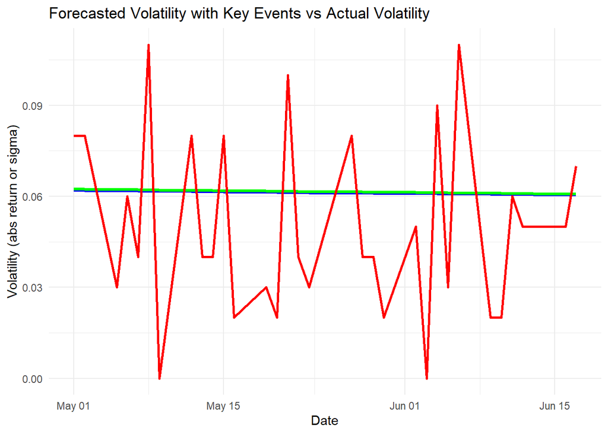

```r
# Plotting the forecasted volatility along with the actual volatility for both the original model and the key event model
ggplot() +
  geom_line(data = forecasted_data, aes(x = Date, y = ForecastedVolatility), color = "blue", size = 1.2) +
  geom_line(data = forecasted_data, aes(x = Date, y = ForecastedVolatilityWithIndicators), color = "green", size = 1.2) +
  geom_line(data = data.frame(Date = index(test_data), ActualVolatility = abs(test_data)), aes(x = Date, y = ActualVolatility), color = "red", linetype = "solid", size = 1) +
  labs(title = "Forecasted Volatility with Key Events vs Actual Volatility",
       y = "Volatility (abs return or sigma)", x = "Date") +
  theme_minimal()
```

### Only the spikes of the events

```r
key_events <- data.frame(
  COVID = ifelse(index(train_data) >= as.Date("2020-01-01") & index(train_data) <= as.Date("2020-05-01"), 1, 0),
  Trump = ifelse(index(train_data) >= as.Date("2022-03-01") & index(train_data) <= as.Date("2022-10-01"), 1, 0),
  Energy = ifelse(index(train_data) >= as.Date("2023-12-01") & index(train_data) <= as.Date("2024-06-15"),1, 0)
)


# Fit GARCH model with indicators
spec_with_indicators <- ugarchspec(
  variance.model = list(
    model = "sGARCH",
    garchOrder = c(1, 1),
    external.regressors = as.matrix(key_events)),
  mean.model = list(
    armaOrder = c(0, 0),
    include.mean = TRUE,
    external.regressors = as.matrix(key_events)
  ),
  distribution.model = "std"
)
fit_with_indicators <- ugarchfit(spec_with_indicators, train_data$Vola)
# Extract residuals and squared residuals with indicators
residuals_train_with_indicators <- residuals(fit_with_indicators, standardize = TRUE)
squared_residuals_train_with_indicators <- residuals(fit_with_indicators, standardize = FALSE)^2
```

```r
fit_with_indicators
```

```
##
## *---------------------------------*
## *          GARCH Model Fit        *
## *---------------------------------*
##
## Conditional Variance Dynamics
## -----------------------------------
## GARCH Model  : sGARCH(1,1)
## Mean Model   : ARFIMA(0,0,0)
## Distribution : std
##
## Optimal Parameters
## ------------------------------------
##         Estimate  Std. Error   t value Pr(>|t|)
## mu      0.000027    0.000757  0.035815 0.971430
## mxreg1 -0.014413    0.006299 -2.288057 0.022134
## mxreg2  0.014459    0.006458  2.238806 0.025169
## mxreg3 -0.001397    0.005280 -0.264623 0.791300
## omega   0.000031    0.000012  2.676915 0.007430
## alpha1  0.050150    0.009315  5.383758 0.000000
## beta1   0.937647    0.012438 75.387079 0.000000
## vxreg1  0.000046    0.000043  1.073853 0.282889
## vxreg2  0.000109    0.000062  1.774040 0.076057
## vxreg3  0.000027    0.000035  0.773770 0.439067
## shape  13.021136    2.281154  5.708136 0.000000
##
## Robust Standard Errors:
##         Estimate  Std. Error   t value Pr(>|t|)
## mu      0.000027    0.000707  0.038389 0.969377
## mxreg1 -0.014413    0.004574 -3.151224 0.001626
## mxreg2  0.014459    0.006237  2.318176 0.020440
## mxreg3 -0.001397    0.004364 -0.320165 0.748843
## omega   0.000031    0.000016  1.906712 0.056558
## alpha1  0.050150    0.014814  3.385368 0.000711
## beta1   0.937647    0.020142 46.552334 0.000000
## vxreg1  0.000046    0.000073  0.622405 0.533676
## vxreg2  0.000109    0.000062  1.773122 0.076208
## vxreg3  0.000027    0.000038  0.712934 0.475886
## shape  13.021136    2.247241  5.794277 0.000000
##
```

[output cut: 58 more lines]

```
## Negative Sign Bias  1.7230 0.08496   *
## Positive Sign Bias  0.1973 0.84362
## Joint Effect        3.0201 0.38853
##
##
## Adjusted Pearson Goodness-of-Fit Test:
## ------------------------------------
##   group statistic p-value(g-1)
## 1    20     236.3    1.836e-39
## 2    30     575.2   9.071e-103
## 3    40     839.8   5.668e-151
## 4    50    1044.2   1.095e-186
##
##
## Elapsed time : 4.241264
```

## Break of structure - Bai-Perron test

```r
# Construct proper data frame with squared returns
squared_df <- data.frame(squared = DGS10_diff^2)

# Apply Bai–Perron test with intercept-only model
break_model <- breakpoints(squared ~ 1, data = squared_df, h = 0.15)

# Summarize breakpoints
summary(break_model)
```

```
##
##   Optimal (m+1)-segment partition:
##
## Call:
## breakpoints.formula(formula = squared ~ 1, h = 0.15, data = squared_df)
##
## Breakpoints at observation number:
##
## m = 1                      3040
## m = 2   579                3025
## m = 3   579           2396 3040
## m = 4   579      1791 2396 3040
## m = 5   579 1222 1801 2396 3040
##
## Corresponding to breakdates:
##
## m = 1
## m = 2   0.149767201241593
## m = 3   0.149767201241593                                     0.619762027935851
## m = 4   0.149767201241593                   0.463269529229177 0.619762027935851
## m = 5   0.149767201241593 0.316088980858769 0.465856182100362 0.619762027935851
##
## m = 1   0.786342472840145
## m = 2   0.782462493533368
## m = 3   0.786342472840145
## m = 4   0.786342472840145
## m = 5   0.786342472840145
##
## Fit:
##
## m   0          1          2          3          4          5
## RSS  1.175e-01  1.135e-01  1.115e-01  1.113e-01  1.109e-01  1.109e-01
## BIC -2.922e+04 -2.934e+04 -2.939e+04 -2.938e+04 -2.938e+04 -2.937e+04
```

```r
# Construct proper data frame with squared returns
squared_df <- data.frame(squared = DGS10_diff^2)

# Convert to zoo object
squared_zoo <- zoo(squared_df$squared, order.by = as.Date(rownames(squared_df)))

# Fit Bai–Perron model
break_model <- breakpoints(squared ~ 1, data = squared_df)

# Get breakpoint indices and convert to dates
bp_indices <- break_model$breakpoints
bp_dates <- as.Date(rownames(squared_df)[bp_indices])
```

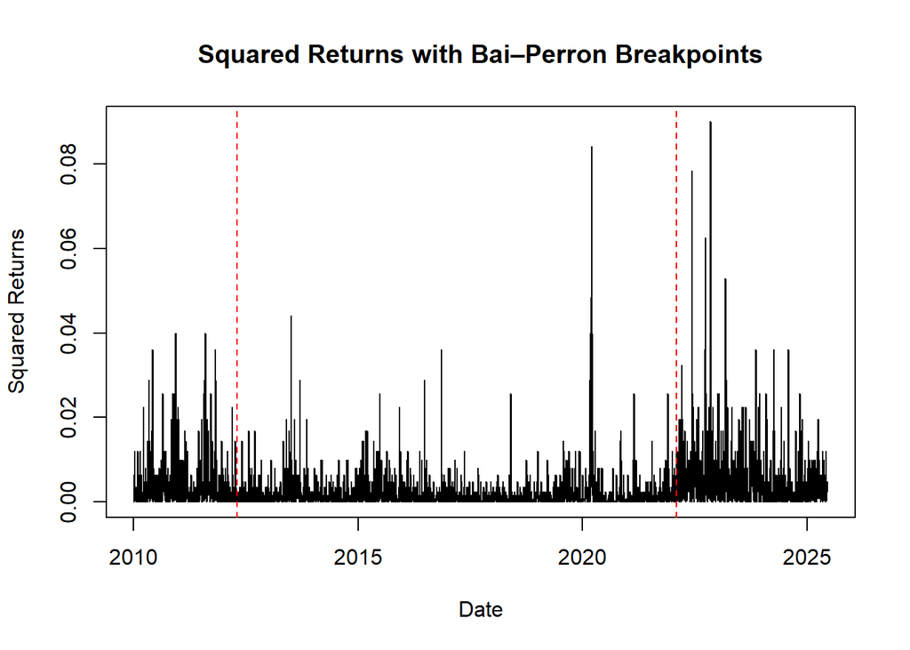

```r
# Plot with actual dates
plot(squared_zoo, type = "l",
     main = "Squared Returns with Bai–Perron Breakpoints",
     xlab = "Date", ylab = "Squared Returns")

# Add vertical lines at breakpoints
abline(v = bp_dates, col = "red", lty = 2)
```

```r
print(bp_dates)
```

```
## [1] "2012-04-24" "2022-02-03"
```

Two breakpoints: 2012-04-24 and 2022-02-03

### New events based on the breakpoints

```r
# Setup
N <- length(DGS10_diff)
forecast_horizon <- 63
full_index <- index(DGS10_diff)
realized_returns <- tail(DGS10_diff, forecast_horizon)
realized_var <- realized_returns^2

# Define rolling predictions container
forecasted_var_with_indicators <- numeric(forecast_horizon)

# Create full event matrix matching the entire series
event_indicators_full <- data.frame(
  Regime1 = ifelse(full_index >= as.Date("2012-04-24") & full_index <= as.Date("2012-10-01"), 1, 0),
  Regime2 = ifelse(full_index >= as.Date("2022-02-03") & full_index <= as.Date("2022-12-01"), 1, 0)
)

# Rolling forecast with external regressors
for (i in 1:forecast_horizon) {

  # Subset data up to time t + i - 1
  train_slice <- DGS10_diff[1:(N - forecast_horizon + i - 1)]
  reg_slice <- event_indicators_full[1:(N - forecast_horizon + i - 1), ]

  # Take the matching regressors for variance equation
  spec_step <- ugarchspec(
    variance.model = list(model = "sGARCH", garchOrder = c(1, 1),
                          external.regressors = as.matrix(reg_slice)),
    mean.model = list(armaOrder = c(0, 0), include.mean = TRUE),
    distribution.model = "std"
  )

  # Fit and forecast
  fit_step <- ugarchfit(spec_step, train_slice, solver = "hybrid", solver.control = list(trace = 0))
  fc <- ugarchforecast(fit_step, n.ahead = 1)
  forecasted_var_with_indicators[i] <- sigma(fc)^2
}
```

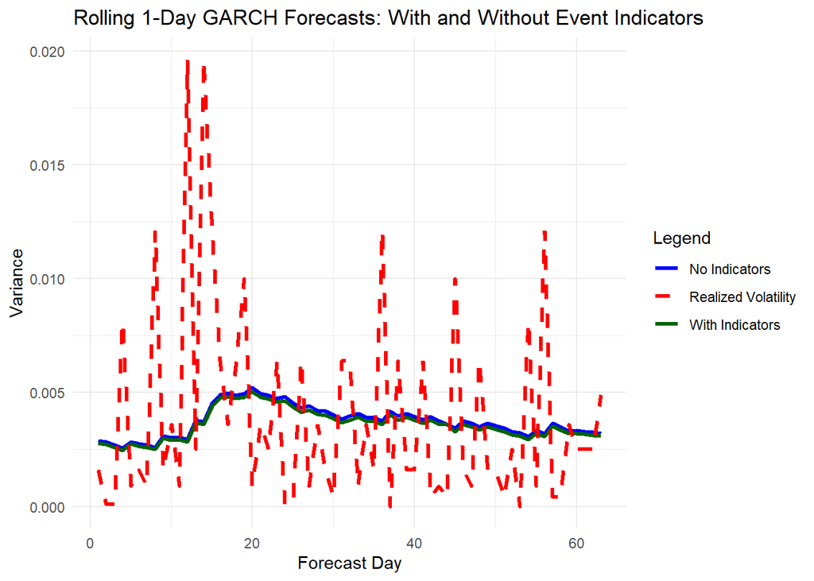

```r
# Comparison dataframe
comparison_df <- data.frame(
  Day = 1:forecast_horizon,
  RealizedVar = realized_var,
  ForecastedVar_NoIndicators = forecasted_var,  # from ugarchroll
  ForecastedVar_Indicators = forecasted_var_with_indicators
)

ggplot(comparison_df, aes(x = Day)) +
  geom_line(aes(y = ForecastedVar_NoIndicators, color = "No Indicators"), size = 1.2) +
  geom_line(aes(y = ForecastedVar_Indicators, color = "With Indicators"), size = 1.2) +
  geom_line(aes(y = RealizedVar, color = "Realized Volatility"), linetype = "dashed", size = 1.2) +
  scale_color_manual(values = c("No Indicators" = "blue",
                                "With Indicators" = "darkgreen",
                                "Realized Volatility" = "red")) +
  labs(
    title = "Rolling 1-Day GARCH Forecasts: With and Without Event Indicators",
    y = "Variance", x = "Forecast Day",
    color = "Legend"
  ) +
  theme_minimal()
```

Now, there is a difference between the blue and the green curves. The blue (no indicators) is usually above the green (with indicators).

```r
key_events <- data.frame(
  Regime1 = ifelse(full_index >= as.Date("2012-04-24") & full_index <= as.Date("2012-10-01"), 1, 0),
  Regime2 = ifelse(full_index >= as.Date("2022-02-03") & full_index <= as.Date("2022-12-01"), 1, 0)
)


# Fit GARCH model with indicators
spec_with_indicators <- ugarchspec(
  variance.model = list(
    model = "sGARCH",
    garchOrder = c(1, 1),
    external.regressors = as.matrix(key_events)),
  mean.model = list(
    armaOrder = c(0, 0),
    include.mean = TRUE,
    external.regressors = as.matrix(key_events)
  ),
  distribution.model = "std"
)
fit_with_indicators <- ugarchfit(spec_with_indicators, train_data$Vola)
# Extract residuals and squared residuals with indicators
residuals_train_with_indicators <- residuals(fit_with_indicators, standardize = TRUE)
squared_residuals_train_with_indicators <- residuals(fit_with_indicators, standardize = FALSE)^2

fit_with_indicators@fit$matcoef
```

```
##             Estimate   Std. Error    t value     Pr(>|t|)
## mu     -9.421433e-05 7.587282e-04 -0.1241740 9.011775e-01
## mxreg1 -3.764211e-03 4.289846e-03 -0.8774701 3.802313e-01
## mxreg2  1.093367e-02 5.524366e-03  1.9791726 4.779657e-02
## omega   3.245284e-05 1.243213e-05  2.6104005 9.043629e-03
## alpha1  5.054287e-02 9.822338e-03  5.1457069 2.665153e-07
## beta1   9.368284e-01 1.328138e-02 70.5369956 0.000000e+00
## vxreg1  4.543822e-06 2.183796e-05  0.2080699 8.351744e-01
## vxreg2  1.214253e-04 5.795644e-05  2.0951128 3.616097e-02
## shape   1.289535e+01 2.242070e+00  5.7515369 8.843579e-09
```

The earlier 2012 breakpoint likely reflects a shift to a lower-volatility environment, but without a statistically distinct impact relative to the base regime once GARCH dynamics are accounted for.

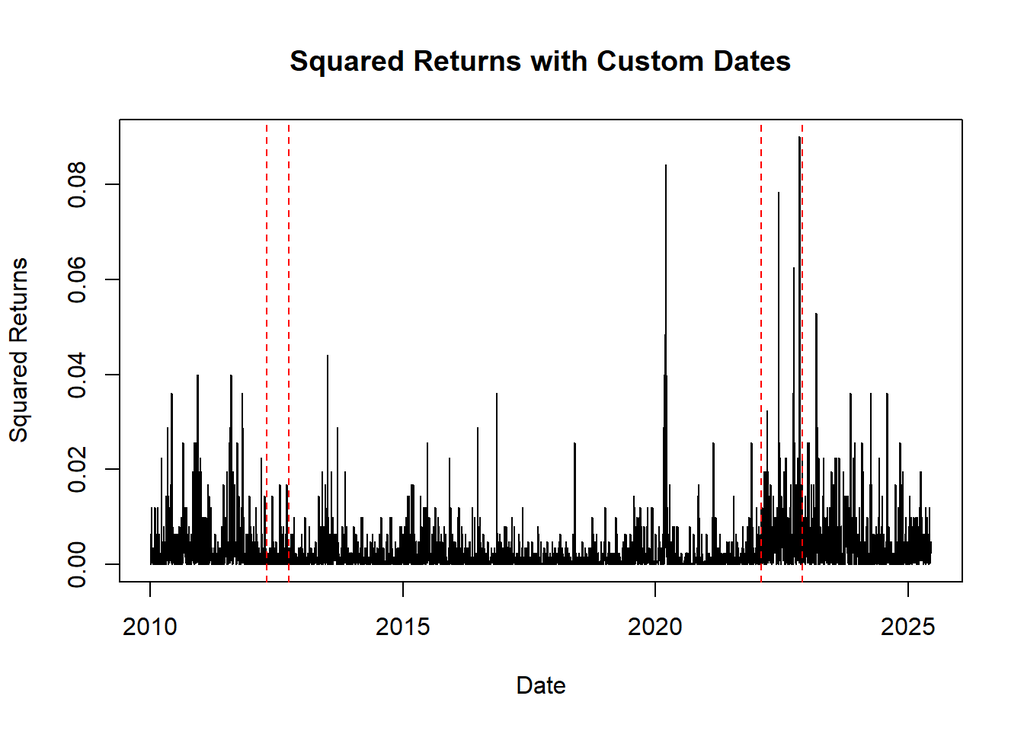

```r
plot(squared_zoo, type = "l",
     main = "Squared Returns with Custom Dates",
     xlab = "Date", ylab = "Squared Returns")

# Add vertical lines at custom dates
custom_dates <- as.Date(c("2012-04-24", "2012-10-01", "2022-02-03", "2022-12-01"))
abline(v = custom_dates, col = "red", lty = 2)
```

### Trying to get a significant variable for COVID

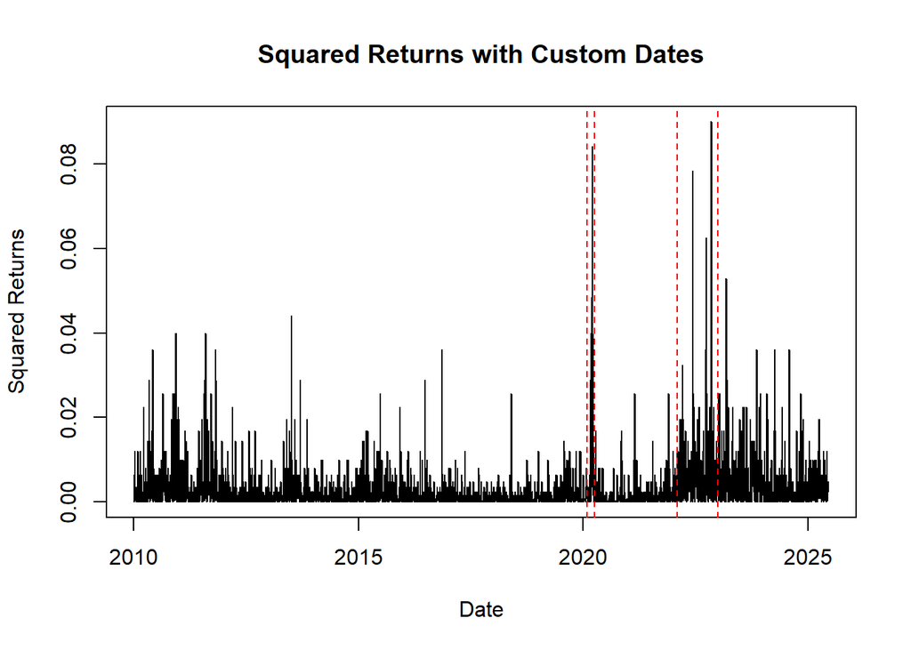

```r
plot(squared_zoo, type = "l",
     main = "Squared Returns with Custom Dates",
     xlab = "Date", ylab = "Squared Returns")

# Add vertical lines at custom dates
custom_dates <- as.Date(c("2020-02-01", "2020-04-01", "2022-02-03", "2023-01-01"))
abline(v = custom_dates, col = "red", lty = 2)
```

#### Both COVID and Energy Crisis

```r
key_events <- data.frame(
  COVID = ifelse(full_index >= as.Date("2020-01-20") & full_index <= as.Date("2020-03-20"), 1, 0),
  Energy = ifelse(full_index >= as.Date("2022-02-03") & full_index <= as.Date("2022-12-01"), 1, 0)
)


# Fit GARCH model with indicators
spec_with_indicators <- ugarchspec(
  variance.model = list(
    model = "sGARCH",
    garchOrder = c(1, 1),
    external.regressors = as.matrix(key_events)),
  mean.model = list(
    armaOrder = c(0, 0),
    include.mean = TRUE,
    external.regressors = as.matrix(key_events)
  ),
  distribution.model = "std"
)
fit_with_indicators <- ugarchfit(spec_with_indicators, train_data$Vola)
# Extract residuals and squared residuals with indicators
residuals_train_with_indicators <- residuals(fit_with_indicators, standardize = TRUE)
squared_residuals_train_with_indicators <- residuals(fit_with_indicators, standardize = FALSE)^2

fit_with_indicators@fit$matcoef
```

```
##             Estimate   Std. Error     t value     Pr(>|t|)
## mu     -5.552334e-05 7.486449e-04 -0.07416513 9.408790e-01
## mxreg1 -2.344442e-02 9.409495e-03 -2.49157016 1.271798e-02
## mxreg2  1.086399e-02 5.521813e-03  1.96746858 4.912921e-02
## omega   3.118421e-05 1.086282e-05  2.87072842 4.095272e-03
## alpha1  4.766104e-02 8.598786e-03  5.54276382 2.977343e-08
## beta1   9.394284e-01 1.144195e-02 82.10388336 0.000000e+00
## vxreg1  1.841055e-04 9.732259e-05  1.89170397 5.853043e-02
## vxreg2  1.206139e-04 5.423566e-05  2.22388539 2.615616e-02
## shape   1.334026e+01 2.396290e+00  5.56704691 2.590927e-08
```

Best indicator for COVID: 2020-01-20 - 2020-03-20. This is almost significant (on the 5% significance level) if we use it together with the other indicator variable. Best indicator for energy crisis: 2022-02-03 - 2022-12-01

#### Only COVID

```r
key_events <- data.frame(
  COVID = ifelse(full_index >= as.Date("2020-01-20") & full_index <= as.Date("2020-03-20"), 1, 0)
)


# Fit GARCH model with indicators
spec_with_indicators <- ugarchspec(
  variance.model = list(
    model = "sGARCH",
    garchOrder = c(1, 1),
    external.regressors = as.matrix(key_events)),
  mean.model = list(
    armaOrder = c(0, 0),
    include.mean = TRUE,
    external.regressors = as.matrix(key_events)
  ),
  distribution.model = "std"
)
fit_with_indicators <- ugarchfit(spec_with_indicators, train_data$Vola)
# Extract residuals and squared residuals with indicators
residuals_train_with_indicators <- residuals(fit_with_indicators, standardize = TRUE)
squared_residuals_train_with_indicators <- residuals(fit_with_indicators, standardize = FALSE)^2

fit_with_indicators@fit$matcoef
```

```
##             Estimate   Std. Error    t value     Pr(>|t|)
## mu      1.464397e-04 7.421065e-04  0.1973298 8.435695e-01
## mxreg1 -2.352386e-02 9.315937e-03 -2.5251203 1.156587e-02
## omega   2.462118e-05 8.731897e-06  2.8196827 4.807115e-03
## alpha1  4.893121e-02 7.807914e-03  6.2668740 3.683680e-10
## beta1   9.423276e-01 9.512151e-03 99.0656653 0.000000e+00
## vxreg1  1.693294e-04 9.172219e-05  1.8461118 6.487598e-02
## shape   1.303038e+01 2.270331e+00  5.7394162 9.500349e-09
```

#### Only the Energy Crisis

```r
key_events <- data.frame(
  Energy = ifelse(full_index >= as.Date("2022-02-03") & full_index <= as.Date("2022-12-01"), 1, 0)
)


# Fit GARCH model with indicators
spec_with_indicators <- ugarchspec(
  variance.model = list(
    model = "sGARCH",
    garchOrder = c(1, 1),
    external.regressors = as.matrix(key_events)),
  mean.model = list(
    armaOrder = c(0, 0),
    include.mean = TRUE,
    external.regressors = as.matrix(key_events)
  ),
  distribution.model = "std"
)
fit_with_indicators <- ugarchfit(spec_with_indicators, train_data$Vola)
# Extract residuals and squared residuals with indicators
residuals_train_with_indicators <- residuals(fit_with_indicators, standardize = TRUE)
squared_residuals_train_with_indicators <- residuals(fit_with_indicators, standardize = FALSE)^2

fit_with_indicators@fit$matcoef
```

```
##             Estimate   Std. Error    t value     Pr(>|t|)
## mu     -0.0002101958 7.474701e-04 -0.2812096 7.785497e-01
## mxreg1  0.0110395542 5.522783e-03  1.9989113 4.561795e-02
## omega   0.0000322785 1.231690e-05  2.6206669 8.775797e-03
## alpha1  0.0503042541 9.692693e-03  5.1899150 2.103901e-07
## beta1   0.9371899669 1.307347e-02 71.6863821 0.000000e+00
## vxreg1  0.0001203983 5.741791e-05  2.0968774 3.600443e-02
## shape  12.9536379205 2.258439e+00  5.7356607 9.713294e-09
```

Interestingly, if we include both the COVID and the Energy Crisis indicators, then we get a better fit (smaller p-values for both variables) than if we use them alone.